# DDS Project 1

Richard and Joaquin

10/23/2021

## **Introduction**

##### **The purpose of this project is to investigate the alcohol by volume (ABV) and international bitterness unit (IBU) values of a variety of beers. Further, we build on our findings regarding ABV and IBU to deliver insights on any differences between IPAs and other types of ales. We also explore the data to provide additional findings on how IPAs and other types of ales are distributed across the US.**

## **Setting up**

### *Loading necessary libraries*

```r
library(tidyverse)
library(ggthemes)
library(scales)
```

```r
library(maps)
library(class) #knn
library(e1071) #naive-bayes
library(caret) #confusion matrix
```

### *Reading in the data*

```r
# We read the data into two different dataframes. Please make sure to modify the directories accordingly.
Beers <- read.csv("D:\\Shared Lenovo\\Data Science\\Semester 1\\Doing Data Science\\Unit 8+9 - DDS Project\\Beers.csv")

Breweries <- read.csv("D:\\Shared Lenovo\\Data Science\\Semester 1\\Doing Data Science\\Unit 8+9 - DDS Project\\Breweries.csv")
```

## **Main Questions of Interest**

### *Question of Interest 1*

##### How many breweries were in each state?

```r
# We pipe the Breweries dataframe in, group calculations by State, and get an aggregate count using n().
Breweries %>%
  count(State) %>%
  head()
```

```
##   State  n
## 1    AK  7
## 2    AL  3
## 3    AR  2
## 4    AZ 11
## 5    CA 39
## 6    CO 47
```

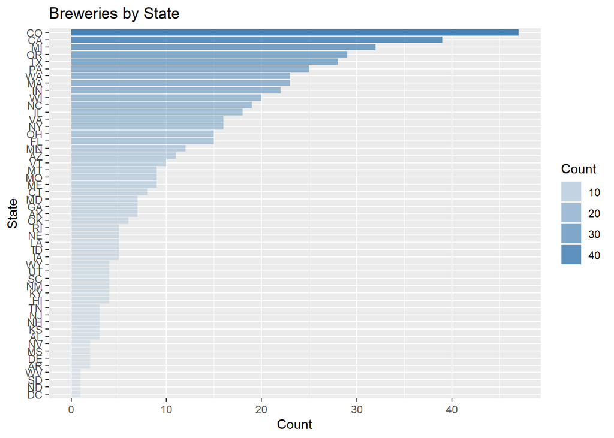

```r
# We plot this into a bar chart to provide a visual.
Breweries %>%
  count(State) %>%
  mutate(State = factor(State,
                        levels = State[order(n, decreasing = FALSE)])) %>%
  ggplot(aes(x = State, y = n, alpha = n)) +
  geom_bar(stat = 'identity', fill = 'steelblue') +
  labs(y = 'Count', alpha = 'Count') +
  ggtitle('Breweries by State') +
  coord_flip()
```

### *Question of Interest 2*

##### Merge the data and print the first and last six observations.

```r
# We conduct a full/outer join to merge the two dataframes, matching based on the brewery IDs from both data frames.
BrewBeer <- full_join(Beers, Breweries, by = c('Brewery_id'='Brew_ID'))
```

```r
# We use head() and tail() to specify the top and bottom six observations of the merged dataframe.
head(BrewBeer, 6)
```

```
##                Name.x Beer_ID   ABV IBU Brewery_id
## 1            Pub Beer    1436 0.050  NA        409
## 2         Devil's Cup    2265 0.066  NA        178
## 3 Rise of the Phoenix    2264 0.071  NA        178
## 4            Sinister    2263 0.090  NA        178
## 5       Sex and Candy    2262 0.075  NA        178
## 6        Black Exodus    2261 0.077  NA        178
##                            Style Ounces                    Name.y City
## 1            American Pale Lager     12 10 Barrel Brewing Company Bend
## 2        American Pale Ale (APA)     12       18th Street Brewery Gary
## 3                   American IPA     12       18th Street Brewery Gary
## 4 American Double / Imperial IPA     12       18th Street Brewery Gary
## 5                   American IPA     12       18th Street Brewery Gary
## 6                  Oatmeal Stout     12       18th Street Brewery Gary
##   State
## 1    OR
## 2    IN
## 3    IN
## 4    IN
## 5    IN
## 6    IN
```

```r
tail(BrewBeer, 6)
```

```
##                           Name.x Beer_ID   ABV IBU Brewery_id
## 2405 Rocky Mountain Oyster Stout    1035 0.075  NA        425
## 2406                   Belgorado     928 0.067  45        425
## 2407               Rail Yard Ale     807 0.052  NA        425
## 2408             B3K Black Lager     620 0.055  NA        425
## 2409         Silverback Pale Ale     145 0.055  40        425
## 2410        Rail Yard Ale (2009)      84 0.052  NA        425
##                         Style Ounces                  Name.y   City State
## 2405           American Stout     12 Wynkoop Brewing Company Denver    CO
## 2406              Belgian IPA     12 Wynkoop Brewing Company Denver    CO
## 2407 American Amber / Red Ale     12 Wynkoop Brewing Company Denver    CO
## 2408              Schwarzbier     12 Wynkoop Brewing Company Denver    CO
## 2409  American Pale Ale (APA)     12 Wynkoop Brewing Company Denver    CO
## 2410 American Amber / Red Ale     12 Wynkoop Brewing Company Denver    CO
```

### *Question of Interest 3*

##### Address missing values.

```r
# We remove any observations that have NA for any variable.
BrewClean <- BrewBeer %>% na.omit()
```

### *Question of Interest 4*

##### What is the median ABV and IBU for each state? Provide a bar chart.

```r
# We pipe the cleaned dataframe in, group calculations by state, and retrieve the median ABV and median IBU for each state.
MedBrew <- BrewClean %>%
  group_by(State) %>%
  summarize(MedianABV = median(ABV),
            MedianIBU = median(IBU))
```

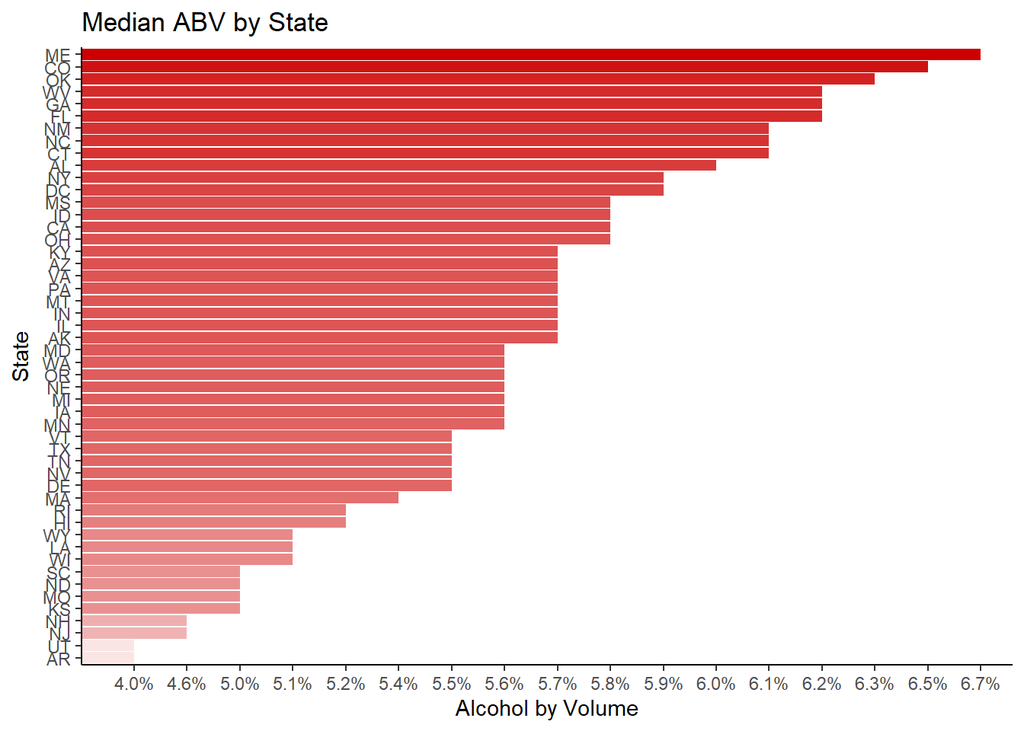

```r
# We first convert the State variable into a factor, determining levels to be the states ordered by median ABV in descending order.
# We then continue piping the converted dataframe into ggplot() to plot the ordered dataframe.
MedBrew %>%
  mutate(State = factor(State,
                        levels = State[order(MedianABV, decreasing = FALSE)])) %>%
  ggplot(aes(x = State, y = percent(MedianABV,accuracy = 0.1), fill = State, alpha = MedianABV)) +
  geom_bar(stat = 'identity', fill = 'red3') +
  labs(y = 'Alcohol by Volume', alpha = 'Median ABV') +
  ggtitle("Median ABV by State") +
  theme_classic() +
  theme(legend.position = "none") +
  coord_flip()
```

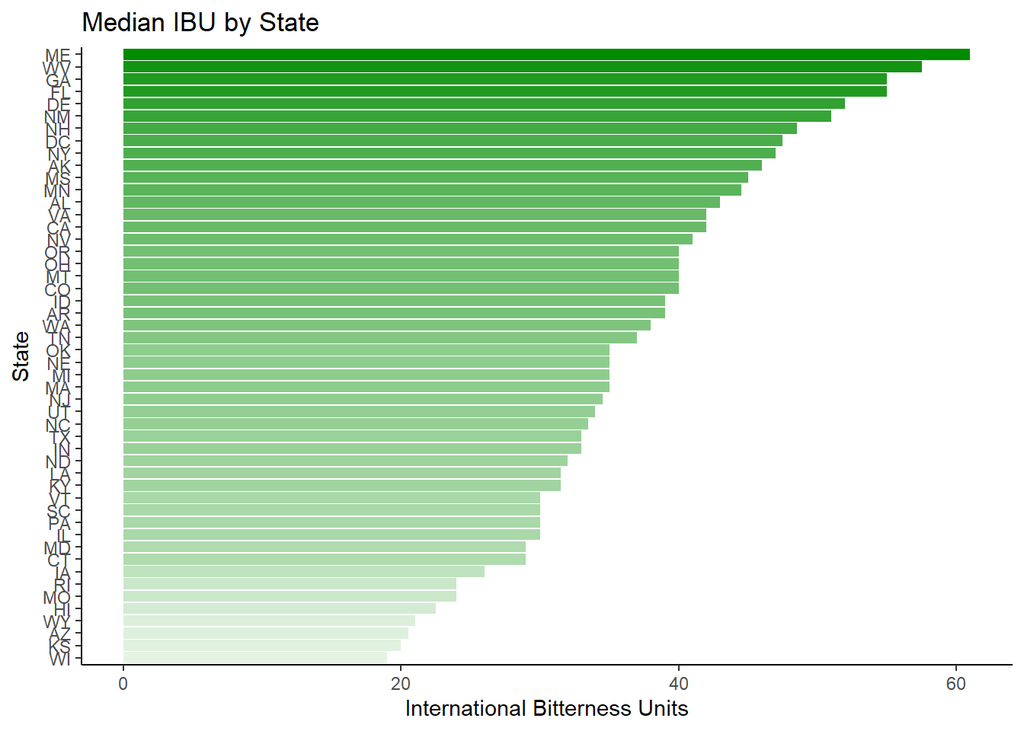

```r
# We conduct the same conversion to the State variable but with median IBU.
# As above, we pipe in the dataframe and plot using ggplot().
MedBrew %>%
  mutate(State = factor(State,
                        levels = State[order(MedianIBU, decreasing = FALSE)])) %>%
  ggplot(aes(x = State, y = MedianIBU, fill = State, alpha = MedianIBU)) +
  geom_bar(stat = 'identity', fill = 'green4') +
  labs(y = 'International Bitterness Units', alpha = 'Median IBU') +
  ggtitle("Median IBU by State") +
  theme_classic() +
  theme(legend.position = "none") +
  coord_flip()
```

### *Question of Interest 5*

##### Which state has the max ABV and which has the highest IBU?

```r
# We use grep() to identify the index where the maximum ABV/IBU values are placed.
# We then pull the State value that is placed in that index.
BrewClean$State[grep(max(BrewClean$ABV),BrewClean$ABV)]
```

```
## [1]  KY
## 51 Levels:  AK  AL  AR  AZ  CA  CO  CT  DC  DE  FL  GA  HI  IA  ID ...  WY
```

```r
BrewClean$State[grep(max(BrewClean$IBU),BrewClean$IBU)]
```

```
## [1]  OR
## 51 Levels:  AK  AL  AR  AZ  CA  CO  CT  DC  DE  FL  GA  HI  IA  ID ...  WY
```

```r
# We also conduct a check by sorting the dataframe and looking at the top values ourselves.
# We filter the variables to ABV, IBU, and State only for easier viewing.
BrewClean %>% arrange(desc(ABV)) %>% dplyr::select(ABV, IBU, State) %>% head(3)
```

```
##     ABV IBU State
## 1 0.125  80    KY
## 2 0.120  90    IN
## 3 0.100  52    NY
```

```r
BrewClean %>% arrange(desc(IBU)) %>% dplyr::select(ABV, IBU, State) %>% head(3)
```

```
##     ABV IBU State
## 1 0.082 138    OR
## 2 0.059 135    VA
## 3 0.090 130    MA
```

### *Question of Interest 6*

##### What are the summary statistics and distribution of ABV?

```r
# We look at the summary statistics for the dataframe.
summary(BrewClean)
```

```
##                     Name.x        Beer_ID          ABV
##  Nonstop Hef Hop       :  12   Min.   :   1   Min.   :0.02700
##  Dale's Pale Ale       :   6   1st Qu.: 772   1st Qu.:0.05000
##  Longboard Island Lager:   4   Median :1439   Median :0.05700
##  1327 Pod's ESB        :   3   Mean   :1415   Mean   :0.05991
##  Boston Lager          :   3   3rd Qu.:2069   3rd Qu.:0.06800
##  Dagger Falls IPA      :   3   Max.   :2692   Max.   :0.12500
##  (Other)               :1374
##       IBU           Brewery_id                               Style
##  Min.   :  4.00   Min.   :  1.0   American IPA                  :301
##  1st Qu.: 21.00   1st Qu.: 95.0   American Pale Ale (APA)       :153
##  Median : 35.00   Median :198.0   American Amber / Red Ale      : 77
##  Mean   : 42.71   Mean   :224.2   American Double / Imperial IPA: 75
##  3rd Qu.: 64.00   3rd Qu.:351.0   American Blonde Ale           : 61
##  Max.   :138.00   Max.   :547.0   American Pale Wheat Ale       : 61
##                                   (Other)                       :677
##      Ounces                           Name.y               City
##  Min.   : 8.40   Oskar Blues Brewery     :  32   Portland    :  41
##  1st Qu.:12.00   Sun King Brewing Company:  32   Indianapolis:  36
##  Median :12.00   Sixpoint Craft Ales     :  23   San Diego   :  35
##  Mean   :13.51   Hopworks Urban Brewery  :  22   Brooklyn    :  28
##  3rd Qu.:16.00   Great Crescent Brewery  :  20   Boulder     :  26
##  Max.   :32.00   Stevens Point Brewery   :  20   Aurora      :  24
##                  (Other)                 :1256   (Other)     :1215
##      State
##   CO    :146
##   CA    :135
##   IN    : 91
##   TX    : 89
##   OR    : 87
##   MA    : 51
##  (Other):806
```

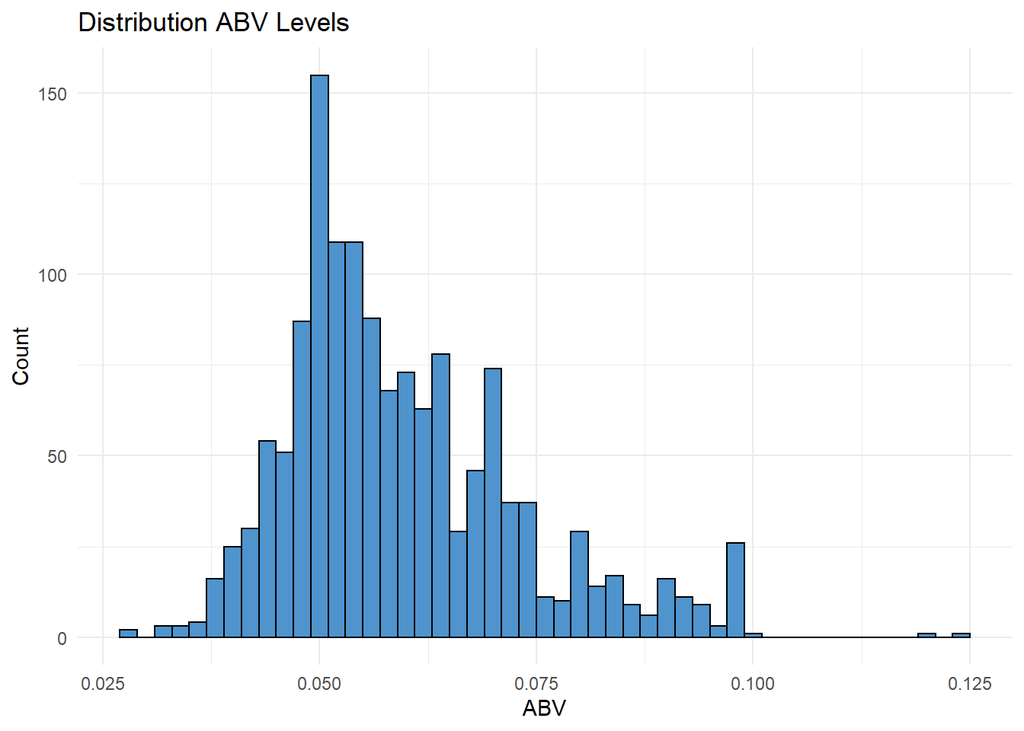

```r
# We use ggplot() to retrieve a histogram of the ABV distribution.
BrewClean %>%
  ggplot(aes(x = ABV)) +
  geom_histogram(bins = 50, color = 'black', fill = 'steelblue3') +
  labs(y = 'Count') +
  ggtitle("Distribution ABV Levels") +
  theme_minimal()
```

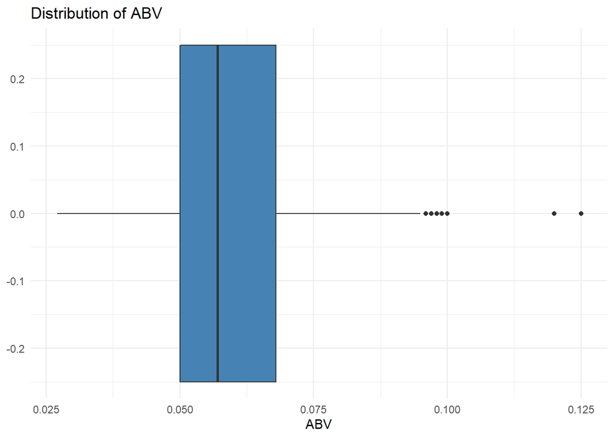

```r
# We also provide a boxplot.
BrewClean %>%
  ggplot(aes(x = ABV)) +
  geom_boxplot(width = 0.5, fill = 'steelblue') +
  #coord_cartesian(xlim=c(-0.5,0.5)) +
  ggtitle('Distribution of ABV') +
  theme_minimal()
```

##### **The ABV variable has a right-skewed distribution, which would imply that more than half of the values fall below the mean 5.99%. We also see that the mean is larger than the median, which implies a right-skewed distribution. However, the summary statistics and histogram show us that the skewness is likely due to the upper outliers in the dataset. This is also apparent when we see the additional boxplot provided.**

### *Question of Interest 7*

##### Is there a relation between IBU and ABV?

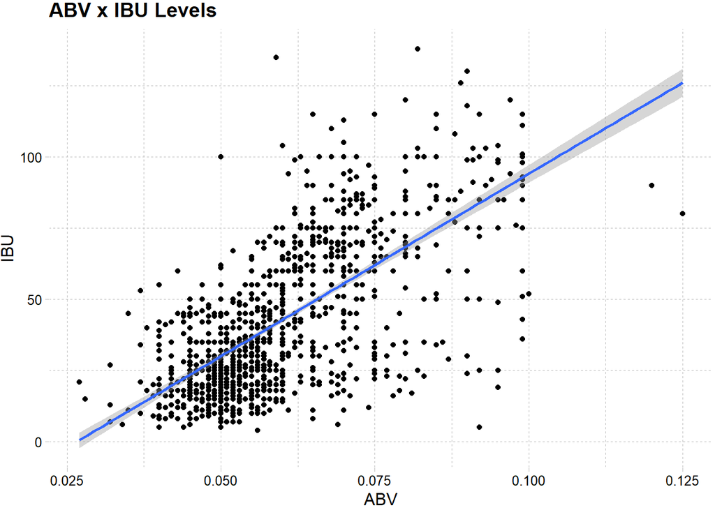

```r
# We use ggplot() to retrieve a scatterplot of the relation between ABV and IBU.
BrewClean %>%
  ggplot(aes(x = ABV, y = IBU)) +
  geom_point() +
  geom_smooth(method = 'lm') +
  ggtitle("ABV x IBU Levels") +
  theme_pander()
```

```r
# We also run a correlation to obtain Pearson's r and quantify the strength of this relation.
cor(BrewClean$ABV, BrewClean$IBU, method = 'pearson')
```

```
## [1] 0.6706215
```

##### **Based on the generated scatterplot and Pearson’s r at 0.67, we know that ABV and IBU have a medium to high positive correlation. This means that higher values of ABV are associated with higher values of IBU and that lower values of ABV are associated with lower values of IBU.**

##### **Please note that, although we observe a strong association between the two variables, we are not making any claims about the direction of the effect.**

### *Question of Interest 8*

##### Investigate the difference between IPAs and other Ales based on ABV and IBU.

```r
# We create a new variable identifying beers as IPA or Ale and remove anything else.
# We also remove extra spaces in the State variable to aid in steps to come.
Ales <- BrewClean %>%
  mutate(BeerType = ifelse(grepl('IPA',Style),'IPA',
                           ifelse(grepl('Ale',Style),'Ale','Neither')),
         State = str_replace_all(State,'\\s+','')) %>%
  filter(BeerType != 'Neither')
```

```r
# We run an external KNN classification model using 70% of the data for training and 30% for testing.
set.seed(50)
trainIndices = sample(1:dim(Ales)[1],round(0.7 * dim(Ales)[1]))
train = Ales[trainIndices,]
test = Ales[-trainIndices,]
model <- knn(train[,c('ABV','IBU')],test[,c('ABV','IBU')],train$BeerType, prob = TRUE, k = 3)
confusionMatrix(table(model,test$BeerType))
```

```
## Confusion Matrix and Statistics
##
##
## model Ale IPA
##   Ale 140  16
##   IPA  20 107
##
##                Accuracy : 0.8728
##                  95% CI : (0.8283, 0.9093)
##     No Information Rate : 0.5654
##     P-Value [Acc > NIR] : <2e-16
##
##                   Kappa : 0.7421
##
##  Mcnemar's Test P-Value : 0.6171
##
##             Sensitivity : 0.8750
##             Specificity : 0.8699
##          Pos Pred Value : 0.8974
##          Neg Pred Value : 0.8425
##              Prevalence : 0.5654
##          Detection Rate : 0.4947
##    Detection Prevalence : 0.5512
##       Balanced Accuracy : 0.8725
##
##        'Positive' Class : Ale
##
```

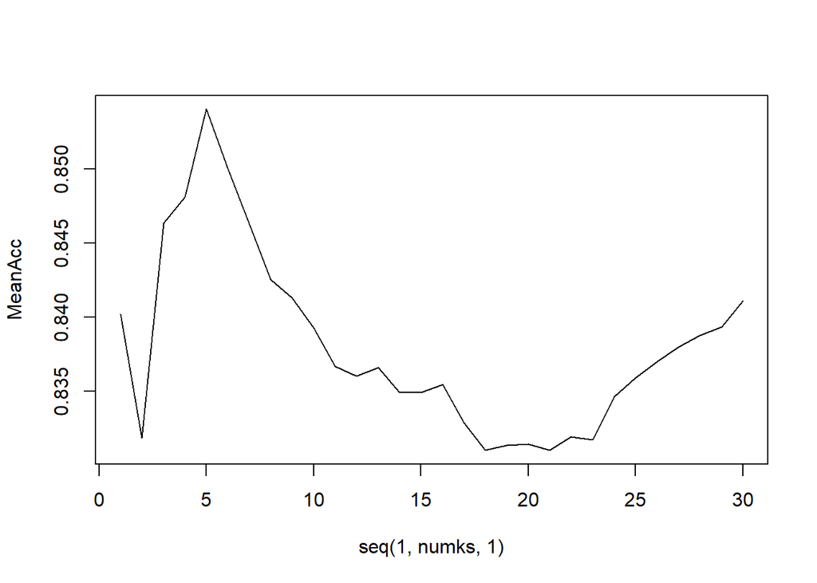

```r
iterations = 50
numks = 30
masterAcc = matrix(nrow = iterations, ncol = numks)

for(j in 1:iterations) {
  accs = data.frame(accuracy = numeric(30), k = numeric(30))
  trainIndices = sample(1:dim(Ales)[1],round(0.7 * dim(Ales)[1]))
  train = Ales[trainIndices,]
  test = Ales[-trainIndices,]
  for(i in 1:numks) {
    classifications = knn(train[,c('ABV','IBU')],test[,c('ABV','IBU')],train$BeerType, prob = TRUE, k = i)
    table(classifications,test$BeerType)
    CM = confusionMatrix(table(classifications,test$BeerType))
    masterAcc[j,i] = CM$overall[1]
  }
}

MeanAcc = colMeans(masterAcc)
plot(seq(1,numks,1),MeanAcc, type = "l")
```

```r
which.max(MeanAcc) # Which inumks is max?
```

```
## [1] 5
```

```r
max(MeanAcc)
```

```
## [1] 0.8540636
```

##### *Additional methods of investigating this relation were not included in the presentation due to time constraints.*

##### *To view them, please scroll down to the end of this file.*

### *Question of Interest 9*

##### What are some additional insights from exploring the data?

```r
# We create a summary of the data to view information by State.
# Please note that we did not use all the summarized variables in our final analyses.
AlesSummary <- Ales %>%
  group_by(State) %>%
  summarize(medianABV = median(ABV),
            medianIBU = median(IBU),
            AleToIPA = sum(BeerType == 'Ale')/sum(BeerType == 'IPA'),
            IPAToAle = sum(BeerType == 'IPA')/sum(BeerType == 'Ale'),
            AlePercent = sum(BeerType == 'Ale')/sum(grepl('IPA|Ale',BeerType)),
            IPAPercent = sum(BeerType == 'IPA')/sum(grepl('IPA|Ale',BeerType))
            ) %>%
  mutate(State = str_replace_all(State,'\\s+',''))
```

```r
# We retrieve a dataframe delineating the boundaries of each US state and change state names to be lowercase.
# This is preparation to join it with our dataframe created above.
states <- map_data("state") %>%
  mutate(State = state.abb[match(region,tolower(state.name))])

# We join the data to our summary dataframe above.
map.df <- full_join(states, AlesSummary, by = 'State')
map.df <- map.df[order(map.df$order),]
```

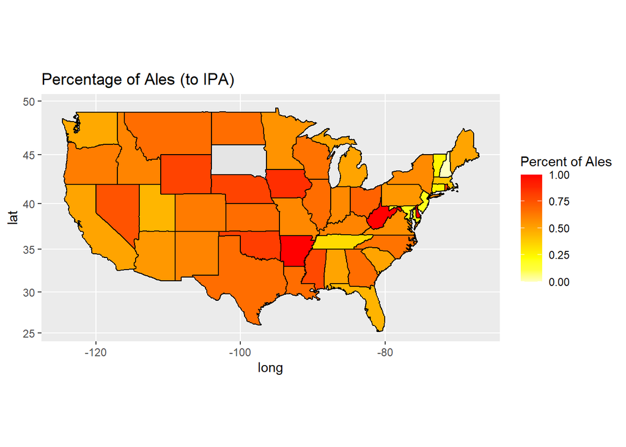

```r
# We plot the data onto a heatmap, filling states based on the percentage of Ales to IPAs.
map.df %>%
  ggplot(aes(x=long,y=lat,group=group))+
  geom_polygon(aes(fill=AlePercent))+
  geom_path()+
  scale_fill_gradientn(colours=rev(heat.colors(10)),na.value="grey90")+
  coord_map() +
  ggtitle("Percentage of Ales (to IPA)") +
  labs(fill = "Percent of Ales")
```

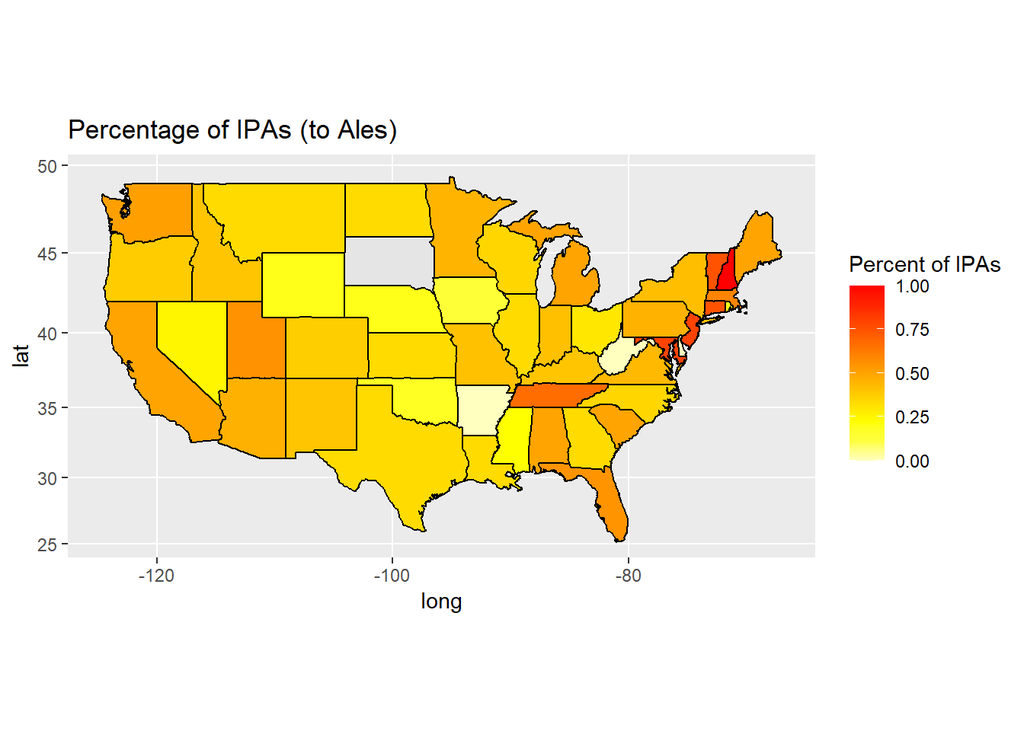

```r
# We plot the data onto a heatmap, filling states based on the percentage of IPAs to Ales.
map.df %>%
  ggplot(aes(x=long,y=lat,group=group))+
  geom_polygon(aes(fill=IPAPercent))+
  geom_path()+
  scale_fill_gradientn(colours=rev(heat.colors(10)),na.value="grey90")+
  coord_map() +
  ggtitle("Percentage of IPAs (to Ales)") +
  labs(fill = "Percent of IPAs")
```

## **Conclusion**

##### **We found that alcohol by volume (ABV) and the international bitterness units (IBU) are important to consider in the context of beers. They also appear to be key factors in determining the difference between IPAs and other types of ales, which may imply that the process from brewing beers to distributing the finalized products for sale should take ABV and IBU into consideration. It is important to note that more data is needed to make such claims. We only mean to highlight to potential importance of ABV and IBU and speculations as to what it could provide.**

##### **We also found that the proportion of IPAs and other ales across the USA differ by state. Although we have no information on the sales, this finding gives us a clue as to where IPAs are more prevalent. However, what this means in terms of action plans is inconclusive. This may serve as a lead for more questions and what other data we should explore for further insights.**

### Additional Methods (not included in the presentation due to time constraints)

```r
# T-Test
Ales %>%
  group_by(BeerType) %>%
  summarize(Count = n(),
            MeanABV = mean(ABV),
            SdABV = sd(ABV),
            MeanIBU = mean(IBU),
            SdIBU = sd(IBU))
```

```
## # A tibble: 2 x 6
##   BeerType Count MeanABV  SdABV MeanIBU SdIBU
##   <chr>    <int>   <dbl>  <dbl>   <dbl> <dbl>
## 1 Ale        552  0.0566 0.0111    34.3  18.0
## 2 IPA        392  0.0691 0.0122    71.9  19.5
```

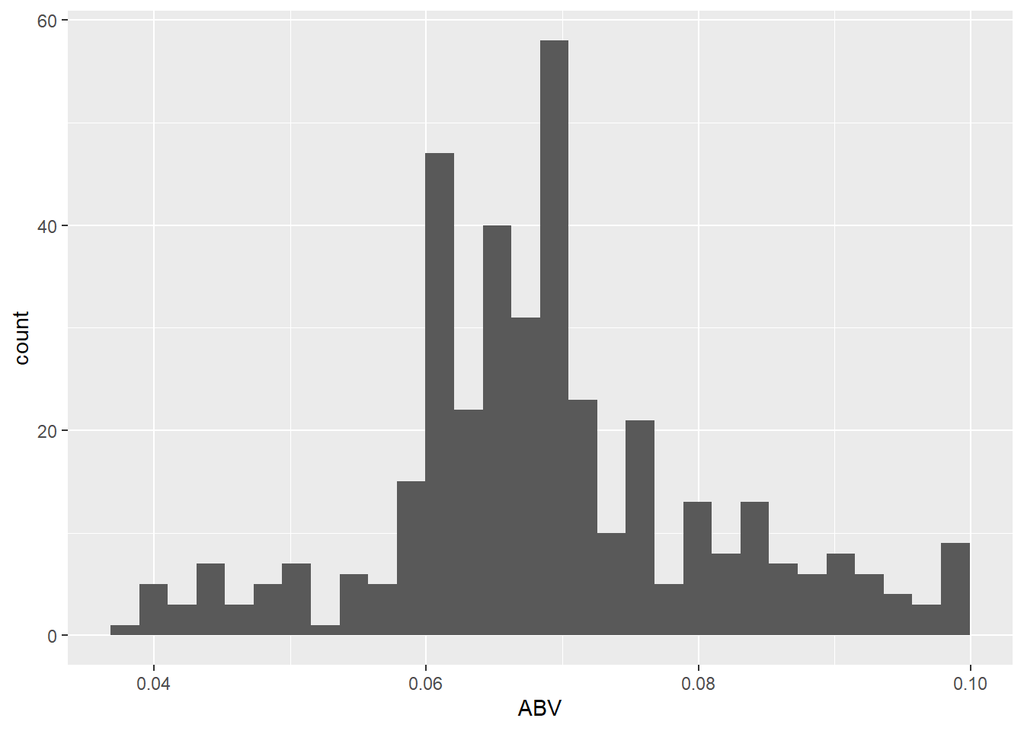

```r
Ales %>% filter(BeerType == 'IPA') %>%
  ggplot(aes(x = ABV)) + geom_histogram()
```

```r
t.test(Ales$ABV ~ Ales$BeerType)
```

```
##
##  Welch Two Sample t-test
##
## data:  Ales$ABV by Ales$BeerType
## t = -16.23, df = 794.65, p-value < 2.2e-16
## alternative hypothesis: true difference in means is not equal to 0
## 95 percent confidence interval:
##  -0.01410901 -0.01106438
## sample estimates:
## mean in group Ale mean in group IPA
##        0.05655616        0.06914286
```

```r
t.test(Ales$IBU ~ Ales$BeerType)
```

```
##
##  Welch Two Sample t-test
##
## data:  Ales$IBU by Ales$BeerType
## t = -30.118, df = 797.55, p-value < 2.2e-16
## alternative hypothesis: true difference in means is not equal to 0
## 95 percent confidence interval:
##  -40.06727 -35.16402
## sample estimates:
## mean in group Ale mean in group IPA
##          34.33333          71.94898
```

```r
# Internal KNN
set.seed(50)
internalmodel <- knn.cv(Ales[c('ABV','IBU')], cl = Ales$BeerType, k = 3)
confusionMatrix(table(internalmodel,Ales$BeerType))
```

```
## Confusion Matrix and Statistics
##
##
## internalmodel Ale IPA
##           Ale 486  69
##           IPA  66 323
##
##                Accuracy : 0.857
##                  95% CI : (0.833, 0.8787)
##     No Information Rate : 0.5847
##     P-Value [Acc > NIR] : <2e-16
##
##                   Kappa : 0.7052
##
##  Mcnemar's Test P-Value : 0.8633
##
##             Sensitivity : 0.8804
##             Specificity : 0.8240
##          Pos Pred Value : 0.8757
##          Neg Pred Value : 0.8303
##              Prevalence : 0.5847
##          Detection Rate : 0.5148
##    Detection Prevalence : 0.5879
##       Balanced Accuracy : 0.8522
##
##        'Positive' Class : Ale
##
```

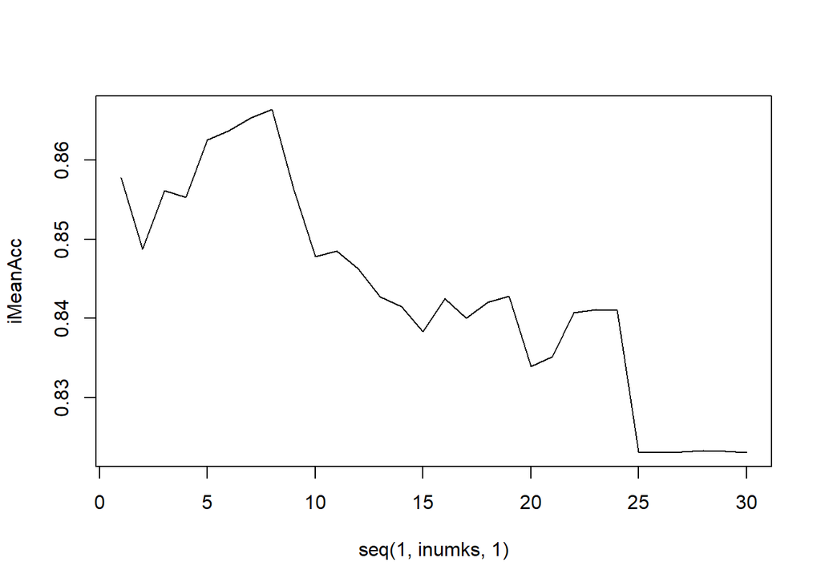

```r
iiterations = 50
inumks = 30

imasterAcc = matrix(nrow = iiterations, ncol = inumks)

# Internal KNN Cross-Validation
for(j in 1:iiterations) {
  for(i in 1:inumks) {
    CM = confusionMatrix(table(knn.cv(Ales[,c('ABV','IBU')],Ales$BeerType, k = i),Ales$BeerType))
    imasterAcc[j,i] = CM$overall[1]
  }
}

iMeanAcc = colMeans(imasterAcc)
plot(seq(1,inumks,1),iMeanAcc, type = "l")
```

```r
which.max(iMeanAcc) # which inumks is max?
```

```
## [1] 8
```

```r
max(iMeanAcc)
```

```
## [1] 0.8663559
```

```r
set.seed(50)
confusionMatrix(table(knn.cv(Ales[,c('ABV','IBU')],Ales$BeerType, k = 8),Ales$BeerType))
```

```
## Confusion Matrix and Statistics
##
##
##       Ale IPA
##   Ale 498  73
##   IPA  54 319
##
##                Accuracy : 0.8655
##                  95% CI : (0.842, 0.8866)
##     No Information Rate : 0.5847
##     P-Value [Acc > NIR] : <2e-16
##
##                   Kappa : 0.721
##
##  Mcnemar's Test P-Value : 0.1102
##
##             Sensitivity : 0.9022
##             Specificity : 0.8138
##          Pos Pred Value : 0.8722
##          Neg Pred Value : 0.8552
##              Prevalence : 0.5847
##          Detection Rate : 0.5275
##    Detection Prevalence : 0.6049
##       Balanced Accuracy : 0.8580
##
##        'Positive' Class : Ale
##
```

```r
# Naive-Bayes
nbtrainIndices = sample(1:dim(Ales)[1],round(0.7 * dim(Ales)[1]))
nbtrain = Ales[nbtrainIndices,]
nbtest = Ales[-nbtrainIndices,]
nbmodel = naiveBayes(nbtrain[,c('ABV','IBU')],nbtrain$BeerType)
confusionMatrix(table(predict(nbmodel,nbtest[,c('ABV','IBU')]),nbtest$BeerType))
```

```
## Confusion Matrix and Statistics
##
##
##       Ale IPA
##   Ale 142  22
##   IPA  22  97
##
##                Accuracy : 0.8445
##                  95% CI : (0.797, 0.8847)
##     No Information Rate : 0.5795
##     P-Value [Acc > NIR] : <2e-16
##
##                   Kappa : 0.681
##
##  Mcnemar's Test P-Value : 1
##
##             Sensitivity : 0.8659
##             Specificity : 0.8151
##          Pos Pred Value : 0.8659
##          Neg Pred Value : 0.8151
##              Prevalence : 0.5795
##          Detection Rate : 0.5018
##    Detection Prevalence : 0.5795
##       Balanced Accuracy : 0.8405
##
##        'Positive' Class : Ale
##
```

```r
nbiterations = 50
nbmasterAcc = matrix(nrow = nbiterations)

for(j in 1:nbiterations) {
  nbtrainIndices = sample(1:dim(Ales)[1],round(0.7 * dim(Ales)[1]))
  nbtrain = Ales[nbtrainIndices,]
  nbtest = Ales[-nbtrainIndices,]

  nbmodel = naiveBayes(nbtrain[,c('ABV','IBU')],nbtrain$BeerType)
  CM = confusionMatrix(table(predict(nbmodel,nbtest[,c('ABV','IBU')]),nbtest$BeerType))
  nbmasterAcc[j] = CM$overall[1]
}

nbMeanAcc = colMeans(nbmasterAcc)
nbMeanAcc
```

```
## [1] 0.8431802
```